# Red Wine Quality Exploration

The guiding question throughout this analysis is to find: Which chemical properties influence the quality of red wine?

## Univariate Plots Section

First we want to familiarize ourselves with our dataset.

Our dataset has 1599 observations and 12 variables. Throughout this analysis we will conduct univariate, bivariate and multivariate analysis.

## Description of the variables

1 - fixed acidity (tartaric acid - g / dm^3) 2 - volatile acidity (acetic acid - g / dm^3) 3 - citric acid (g / dm^3) 4 - residual sugar (g / dm^3) 5 - chlorides (sodium chloride - g / dm^3) 6 - free sulfur dioxide (mg / dm^3) 7 - total sulfur dioxide (mg / dm^3) 8 - density (g / cm^3) 9 - pH (unitless) 10 - sulphates (potassium sulphate - g / dm3) 11 - alcohol (% by volume) 12 - quality (score between 0 and 10)

```
## 'data.frame':    1599 obs. of  13 variables:
##  $ X                   : int  1 2 3 4 5 6 7 8 9 10 ...
##  $ fixed.acidity       : num  7.4 7.8 7.8 11.2 7.4 7.4 7.9 7.3 7.8 7.5 ...
##  $ volatile.acidity    : num  0.7 0.88 0.76 0.28 0.7 0.66 0.6 0.65 0.58 0.5 ...
##  $ citric.acid         : num  0 0 0.04 0.56 0 0 0.06 0 0.02 0.36 ...
##  $ residual.sugar      : num  1.9 2.6 2.3 1.9 1.9 1.8 1.6 1.2 2 6.1 ...
##  $ chlorides           : num  0.076 0.098 0.092 0.075 0.076 0.075 0.069 0.065 0.073 0.071 ...
##  $ free.sulfur.dioxide : num  11 25 15 17 11 13 15 15 9 17 ...
##  $ total.sulfur.dioxide: num  34 67 54 60 34 40 59 21 18 102 ...
##  $ density             : num  0.998 0.997 0.997 0.998 0.998 ...
##  $ pH                  : num  3.51 3.2 3.26 3.16 3.51 3.51 3.3 3.39 3.36 3.35 ...
##  $ sulphates           : num  0.56 0.68 0.65 0.58 0.56 0.56 0.46 0.47 0.57 0.8 ...
##  $ alcohol             : num  9.4 9.8 9.8 9.8 9.4 9.4 9.4 10 9.5 10.5 ...
##  $ quality             : int  5 5 5 6 5 5 5 7 7 5 ...
```

```
##        X          fixed.acidity   volatile.acidity  citric.acid
##  Min.   :   1.0   Min.   : 4.60   Min.   :0.1200   Min.   :0.000
##  1st Qu.: 400.5   1st Qu.: 7.10   1st Qu.:0.3900   1st Qu.:0.090
##  Median : 800.0   Median : 7.90   Median :0.5200   Median :0.260
##  Mean   : 800.0   Mean   : 8.32   Mean   :0.5278   Mean   :0.271
##  3rd Qu.:1199.5   3rd Qu.: 9.20   3rd Qu.:0.6400   3rd Qu.:0.420
##  Max.   :1599.0   Max.   :15.90   Max.   :1.5800   Max.   :1.000
##  residual.sugar     chlorides       free.sulfur.dioxide
##  Min.   : 0.900   Min.   :0.01200   Min.   : 1.00
##  1st Qu.: 1.900   1st Qu.:0.07000   1st Qu.: 7.00
##  Median : 2.200   Median :0.07900   Median :14.00
##  Mean   : 2.539   Mean   :0.08747   Mean   :15.87
##  3rd Qu.: 2.600   3rd Qu.:0.09000   3rd Qu.:21.00
##  Max.   :15.500   Max.   :0.61100   Max.   :72.00
##  total.sulfur.dioxide    density             pH          sulphates
##  Min.   :  6.00       Min.   :0.9901   Min.   :2.740   Min.   :0.3300
##  1st Qu.: 22.00       1st Qu.:0.9956   1st Qu.:3.210   1st Qu.:0.5500
##  Median : 38.00       Median :0.9968   Median :3.310   Median :0.6200
##  Mean   : 46.47       Mean   :0.9967   Mean   :3.311   Mean   :0.6581
##  3rd Qu.: 62.00       3rd Qu.:0.9978   3rd Qu.:3.400   3rd Qu.:0.7300
##  Max.   :289.00       Max.   :1.0037   Max.   :4.010   Max.   :2.0000
##     alcohol         quality
##  Min.   : 8.40   Min.   :3.000
##  1st Qu.: 9.50   1st Qu.:5.000
##  Median :10.20   Median :6.000
##  Mean   :10.42   Mean   :5.636
##  3rd Qu.:11.10   3rd Qu.:6.000
##  Max.   :14.90   Max.   :8.000
```

We will start looking at the histograms of the variables. Note that the first variable “X” is just counting the number of observations. Hence, we do not need a plot for that. We want to see the distributions of the variables and whether there are outliers.

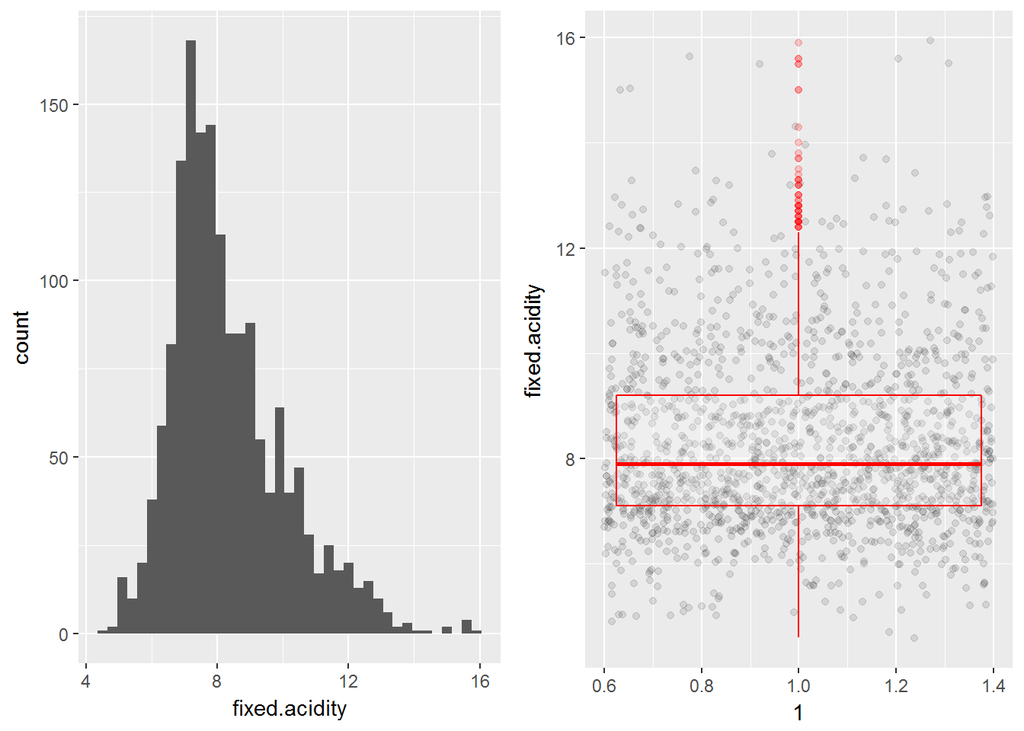

The variable ‘fixed acidity’ has a slighty right-skewed distribution, with a median value of 7.9 and a mean value of 8.32. The red points in our boxplot show the presence of outliers. Indeed, the data indicates that the maximum value of this variable is 15.9. The 1st quartile is at 7.1, while the 3rd quartile is at 9.2.

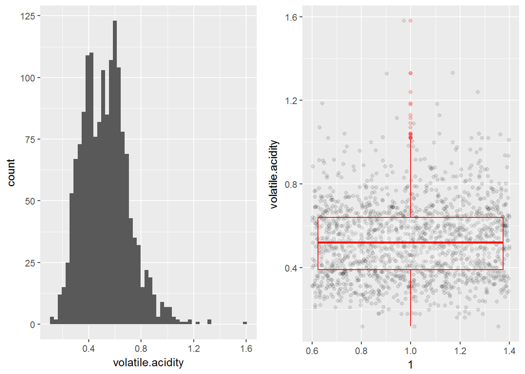

The variable ‘volatile acidity’ also has a slightly right-skewed distribution, with a median value of 0.52 and a mean value of 0.53. The 1st quartile is 0.39 and the 3rd quartile is 0.64. The red points on the right graph show the presence of outliers. The maximum value is 1.58, which is around 3 times more than the mean.

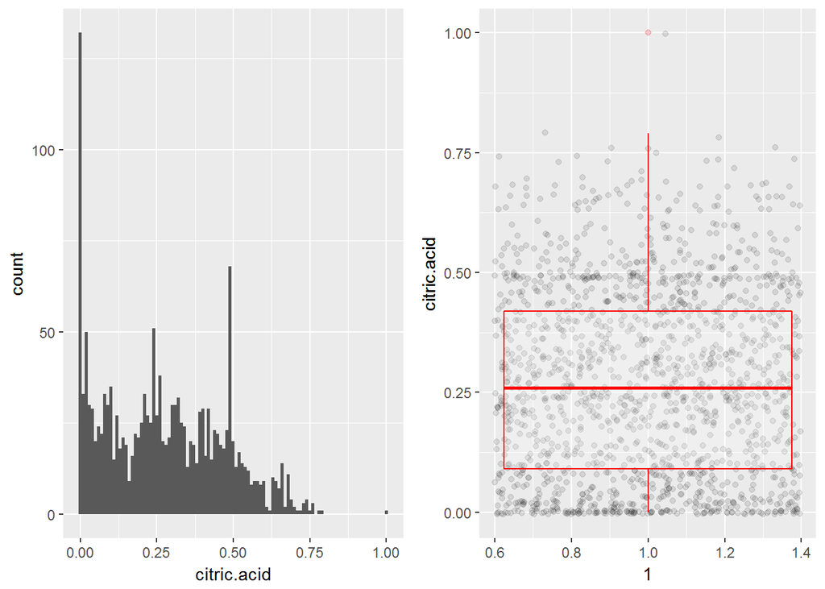

Notice that the highest frequency of the citric acid value is 0. The distribution is right-skewed with a median value of 0.26 and a mean of 0.27. There is just one outlier: the citric acid value of 1. The 1st quartile is 0.09, while the 3rd quartile is 0.42.

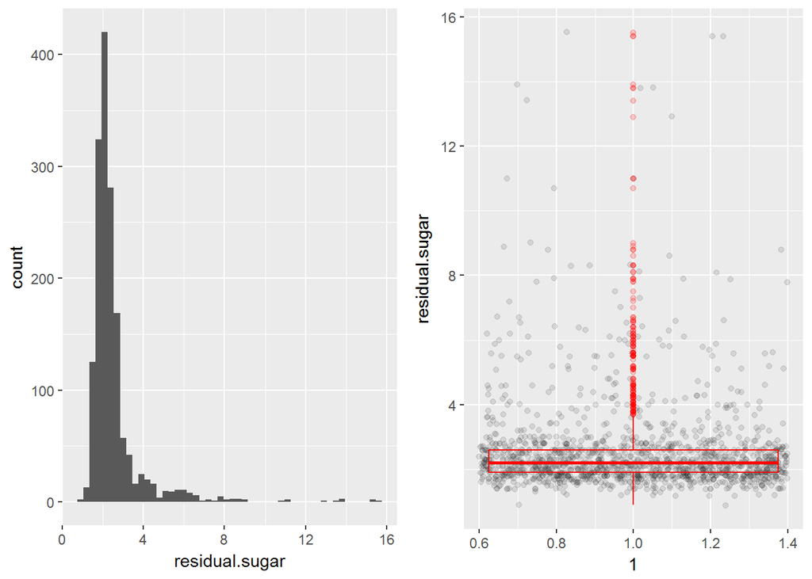

Looking at the plots for the variable ‘residual sugar’, we can see a right-skewed distribution, which is confirmed by the presence of very many outliers in our boxplot. The values range from 0.9 to 15.5, with a mean of 2.54 and a median of 2.2. The 1st quartile is 1.9 and the 3rd quartile is 2.6.

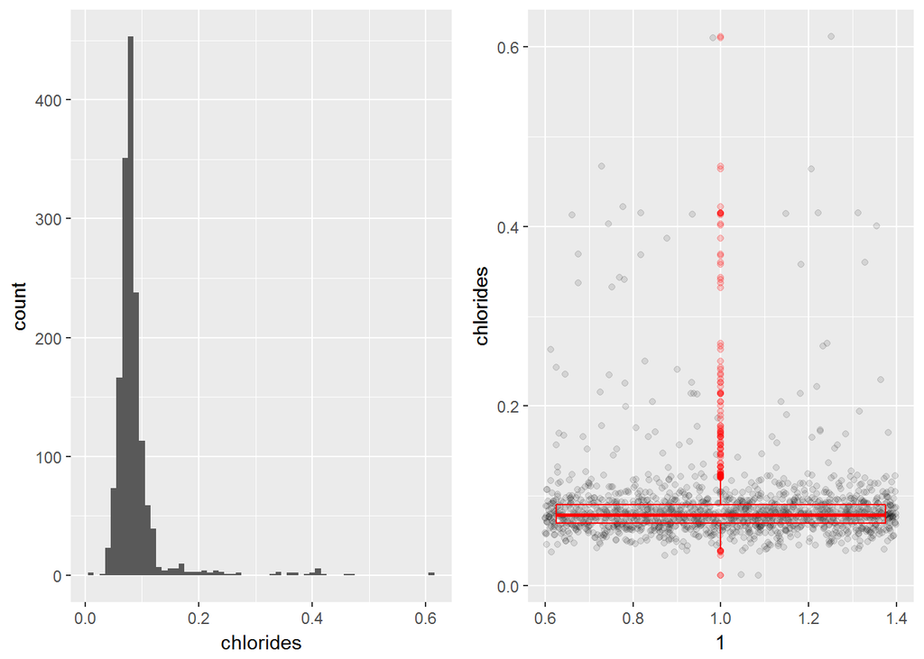

The distribution of the variable ‘chlorides’ is very similar to the distribution of ‘residual sugar’. It is also heavily right-skewed, with a lot of outliers. The median value is 0.079 and the mean is 0.087. The 1st quartile is 0.07 and the 3rd quartile is 0.09.

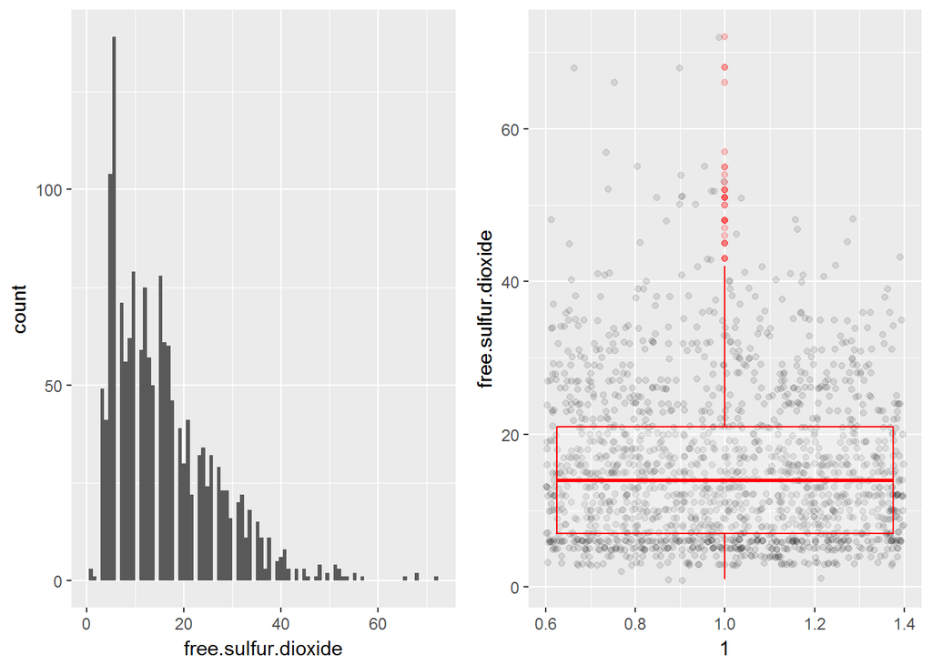

‘Free sulfur dioxide’ has a right-skewed distribution. The red points in the boxplot indicate that there are outliers. The values range from 1 to 72, with a median of 14 and a mean of 15.87. The 1st quartile is 7, while the 3rd quartile is 21.

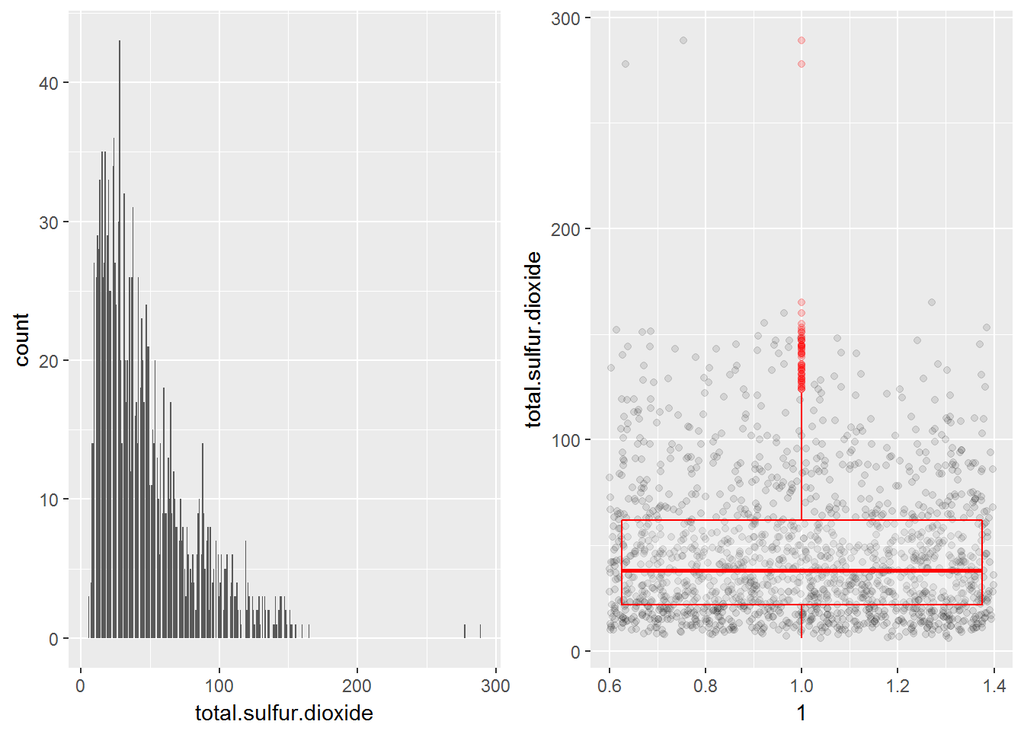

The distribution of the variable ‘total sulfur dioxide’ is skewed to the right. The boxplot indicates the presence of outliers, with a median value of 38. The values range from 6 to 289, with a mean of 46.5. The 1st quartile is 22 and the 3rd quartile is 62.

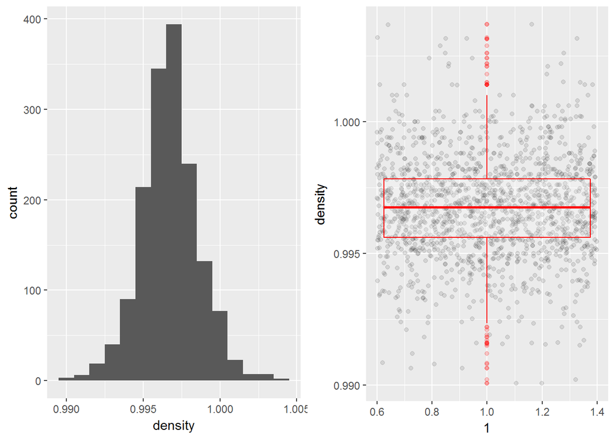

We can notice that the distribution of the variable ‘density’ is normal. Indeed the medain and the mean are close to each other. Namely they are 0.9968 and 0.9967 respectively. The redpoints in the boxplot indicate the presence of outliers above and below the median. The 1st quartile and 3rd quartile are pretty close to each other as well, with values of 0.9956 and 0.9978, respectively.

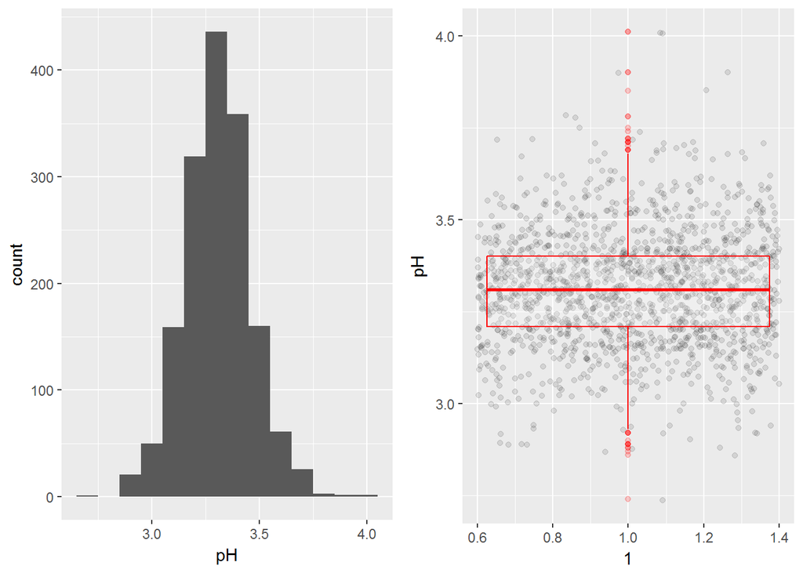

‘pH’ is also a normally distributed variable with a median and mean equal to 3.31. There are a few outliers above and below the median, as shown in the boxplot on the right. The 1st and 3rd quartile are also close to each other, with values of 3.21 and 3.4, respectively.

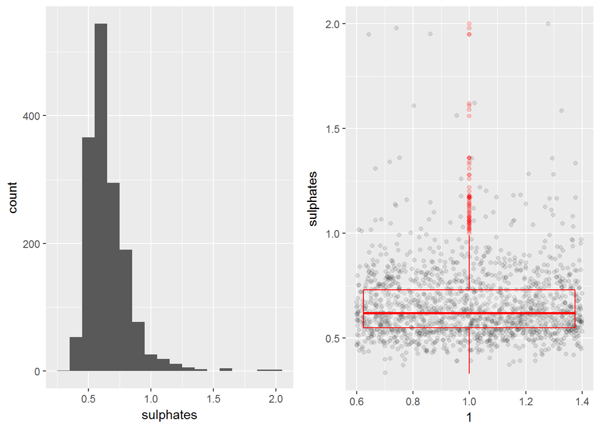

‘Sulphates’ has a distribution skewed to the right, with many outliers. The values range from 0.33 to 2.0. The median value is 0.62 and the mean is 0.66. The 1st quartile is 0.55 and the 3rd quartile is 0.73.

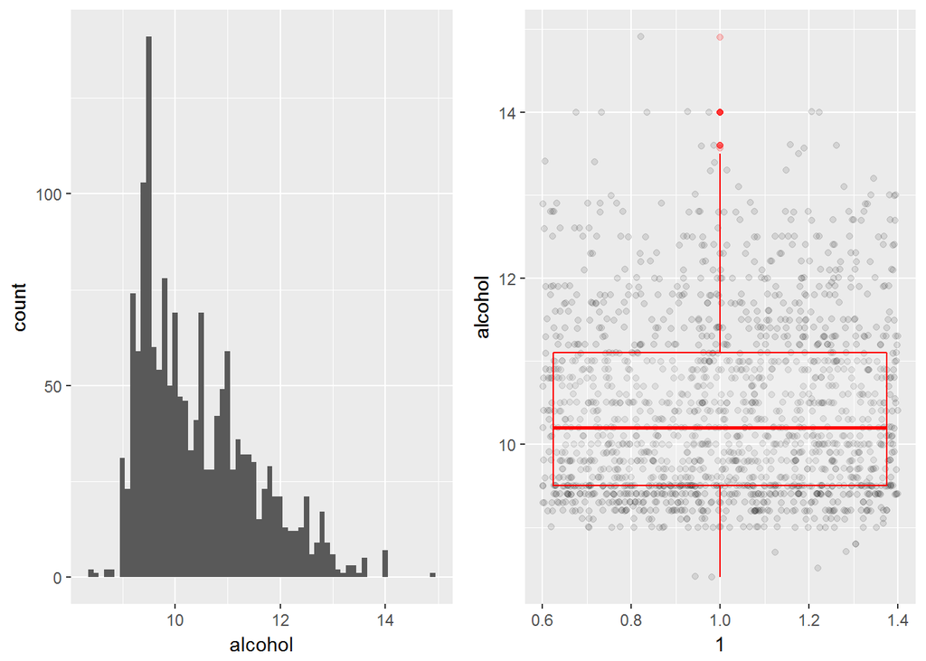

The variable ‘alcohol’ has a right-skewed distribution with very few outliers. The maximum value of 14.9 is an example of such an outlier. The median value is 10.2 and the mean is 10.4. The 1st quartile is 9.5 and the 3rd quartile is 11.1.

The variables ‘density’ and ‘pH’ have normal distributions. The variables ‘fixed acidity’, ‘volatile acidity’, ‘citric acid’, ‘residual sugar’, ‘chlorides’, ‘free sulfur dioxide’, ‘total sulfur dioxide’, ‘sulphates’ and ‘alcohol’ have right-skewed distributions. We will apply log10 transformations to these variables to normalize their distributions.

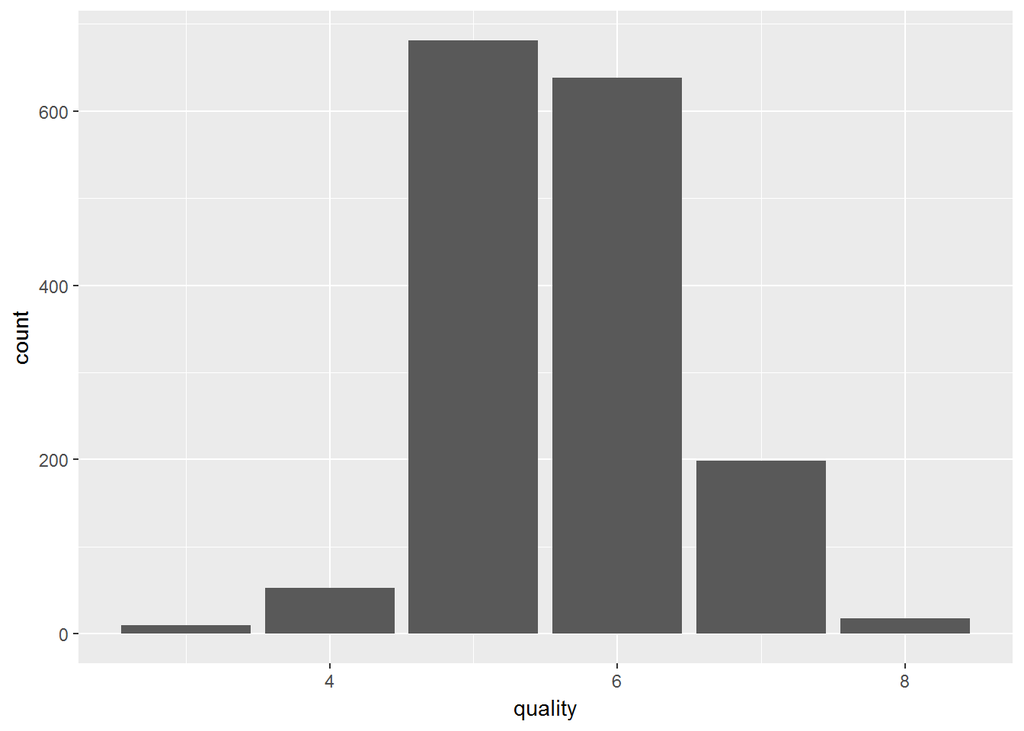

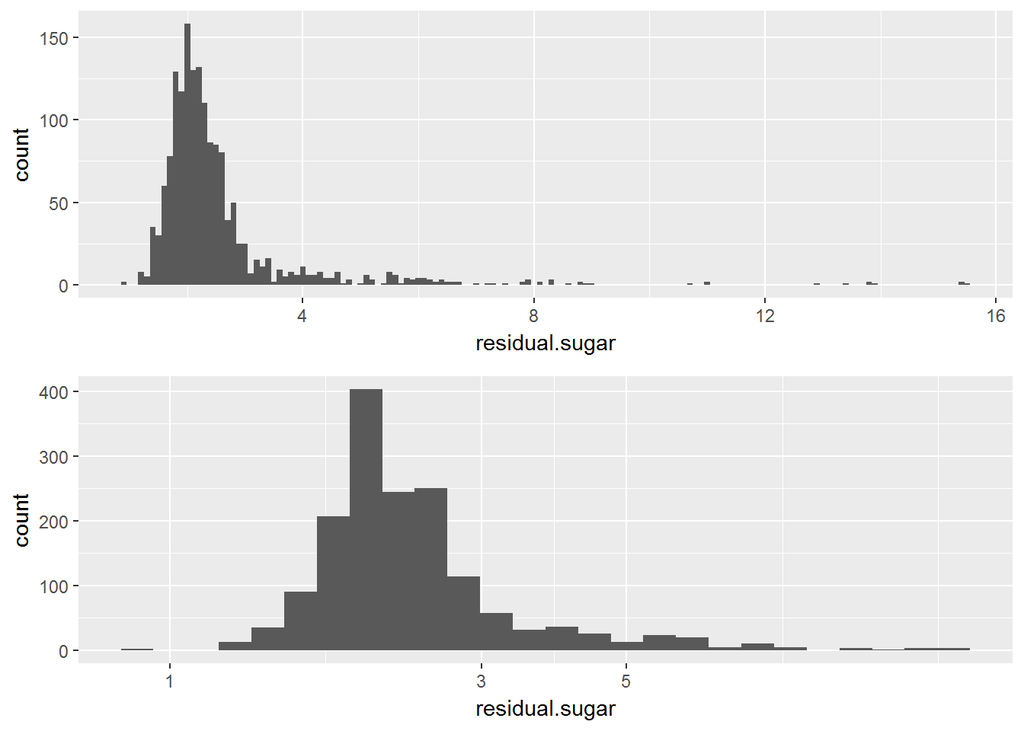

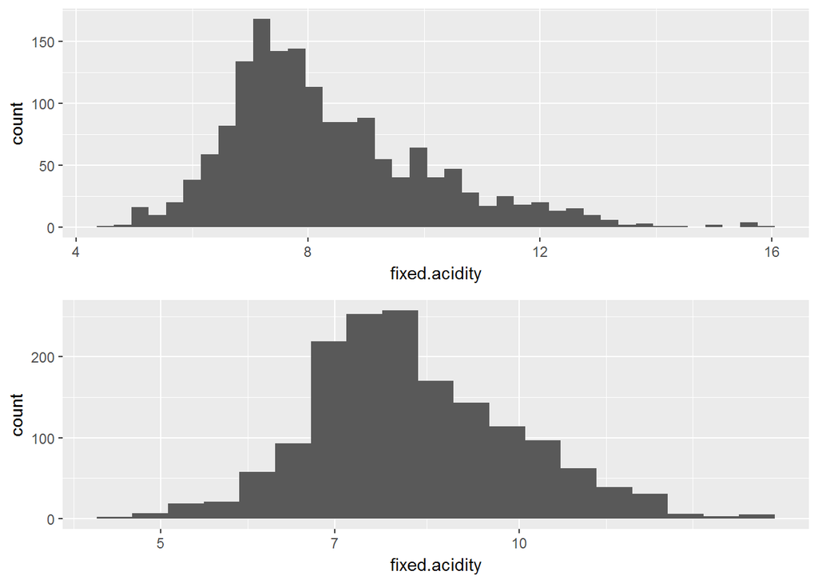

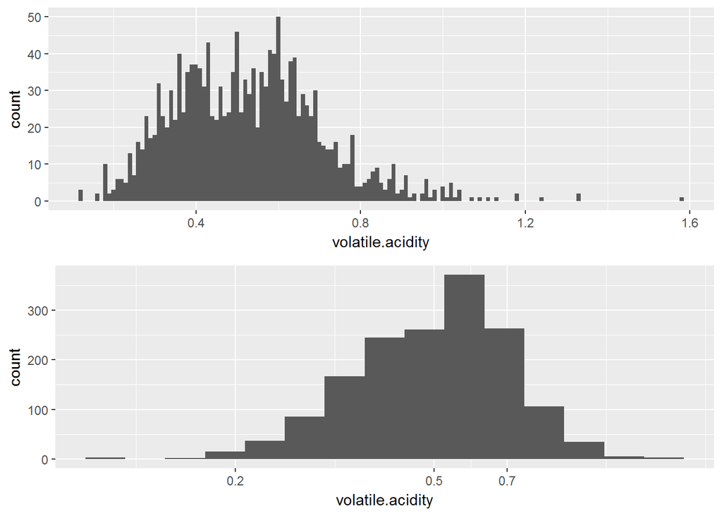

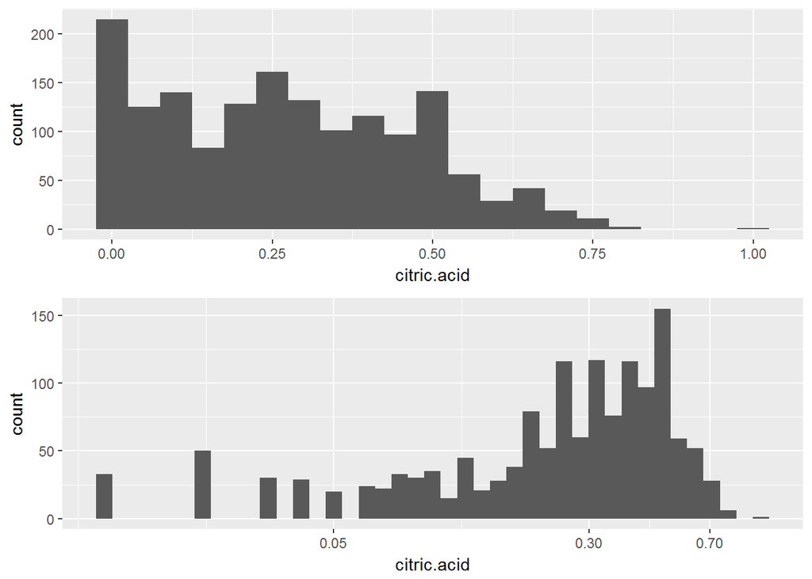

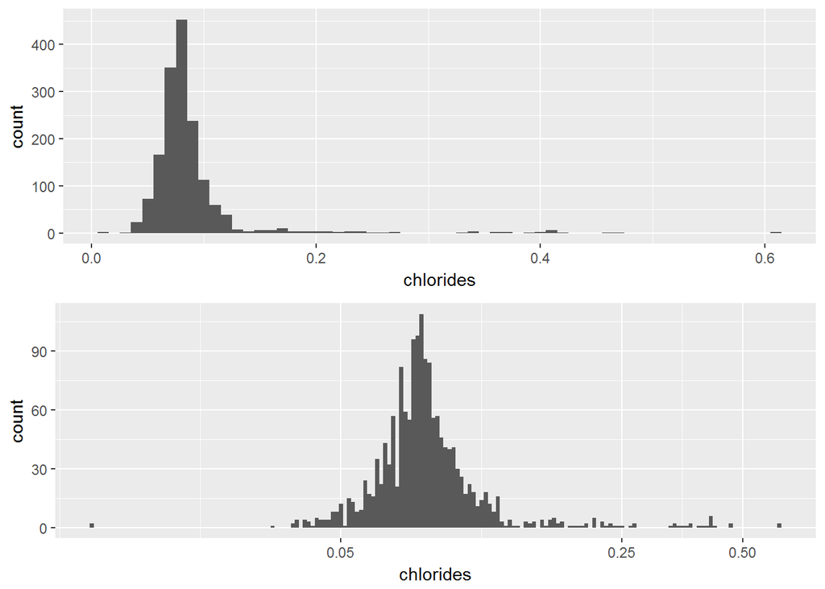

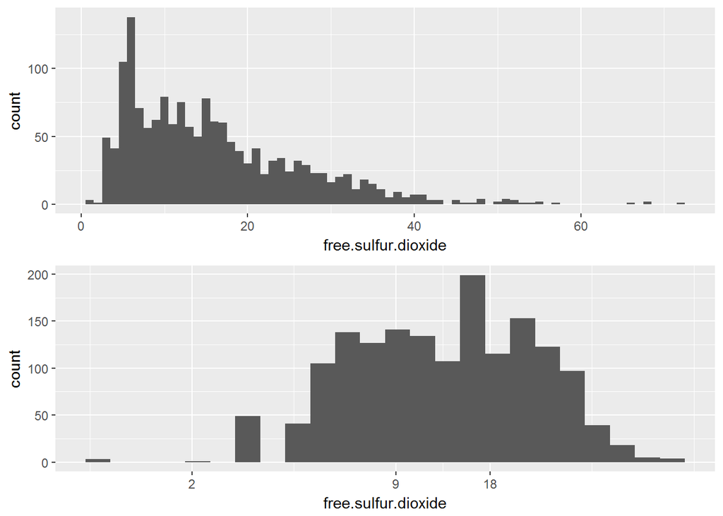

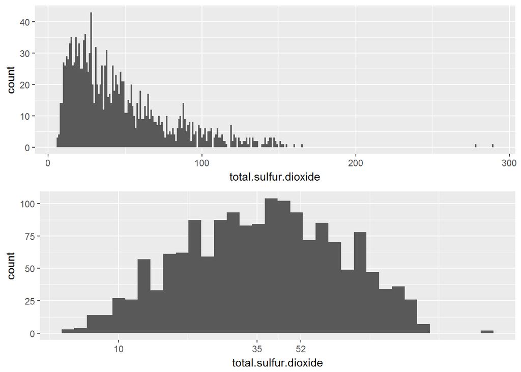

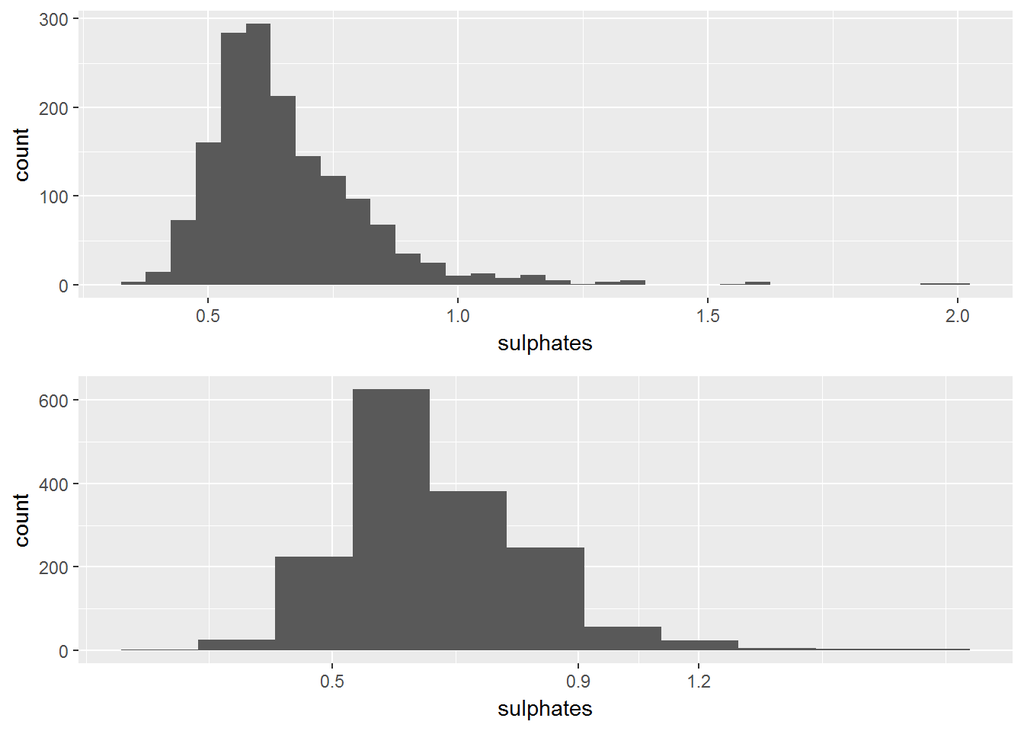

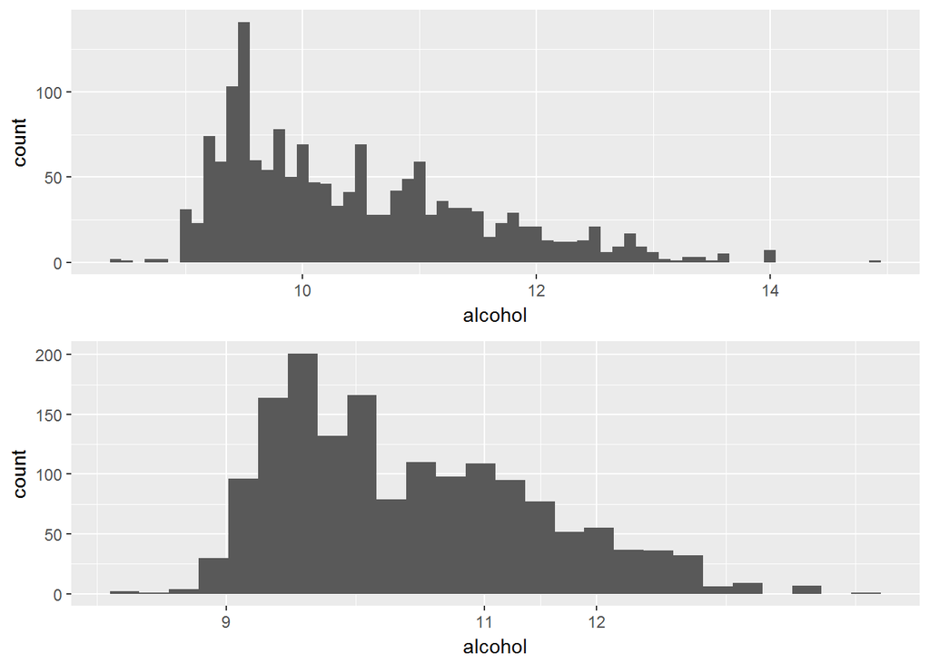

# Univariate Analysis

There are 1599 observations and 12 variables (fixed acidity, volatile acidity, citric acid, residual sugar, chlorides, free sulfur dioxide, total sulfur dioxide, density, pH, sulphates, alcohol and quality). Most red wines in this dataset have a quality rank of 5 and 6. The median alcohol level is 10.2 %, with values ranging from 8.4% to 14.9%. The median pH level is 3.31, with values ranging from 2.74 to 4.01. The median quality level is 6, with values ranging from 3 to 8.

So far we can only see the distributions of the variables. To further understand the relationships between the variables and how they relate to the quality of the wine, we will use the bivariate analysis.

Because the majority of these variables have right-skewed distributions, we used the log10 transformation to normalize those distributions. Namely, these variables are: fixed acidity, volatile acidity, citric acid, residual sugar, chlorides, free sulfur dioxides, total sulfur dioxide, sulphates and alcohol.

We have not created any new variable because it is not adequate for this case. Hence, we will pursue our analysis with the 12 variables at hand.

# Bivariate Plots Section

We will investigate the relationship between the variables in this section. We will start with the correlations.

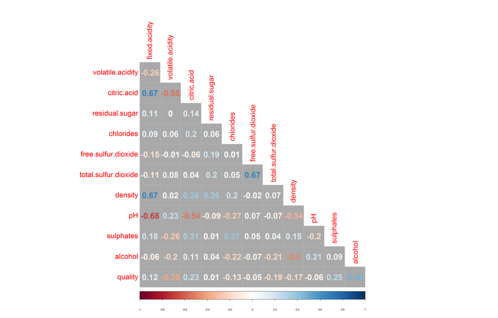

If we have a look at the correlations plot, we can see that alcohol has the strongest correlation with quality (0.48). Based on some additional research, we can see that this makes sense. The alcohol content of the wine is indeed a crucial key to its quality. Besides alcohol, notice that we have only 3 more variables that are positively associated with quality: fixed acidiy, citric acid and sulphates. I do not mention the variable ‘residual sugar’ because the correlation is almost 0 (0.01). The largest positive correlation in this plot is 0.67 and the largest negative correlation is -0.68.

We will have a look at the scatterplots of the variables that are most correlated with each other.

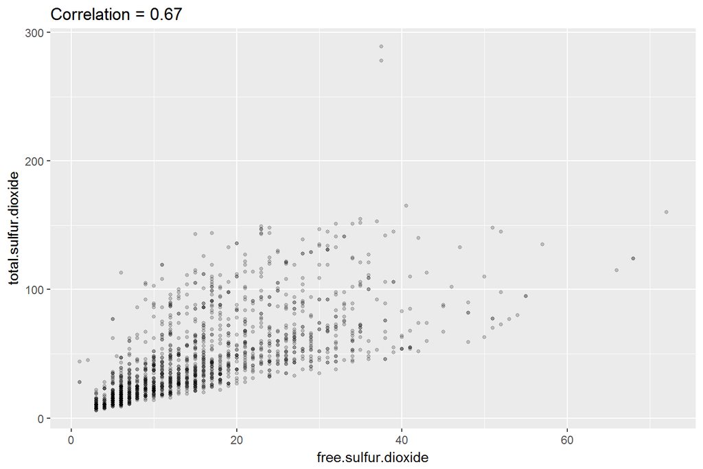

We can observe the positive correlation of 0.67 between free sulfur dioxide and total sulfur dioxide on this scatterplot. Notice that most of the datapoints are clustered in the lower range of the values for both variables. This positive association is to be expected because free sulfur dioxide is part of the total sulfur dioxide.

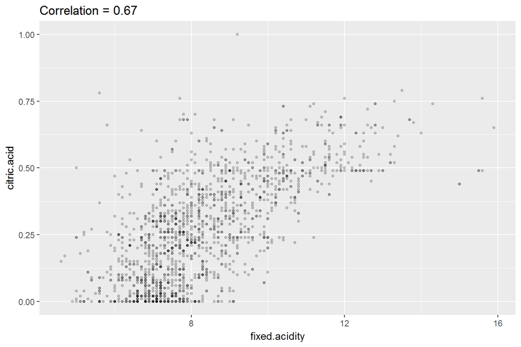

Notice that in the relationship between fixed acidity and citric acid, the data points are more uniformly dispersed. I.e. we do not have a clustering at a certain range of values. The correlation is rather strong (+0.67) and it makes sense. Citric acid is a type of the fixed acids used in wine production.

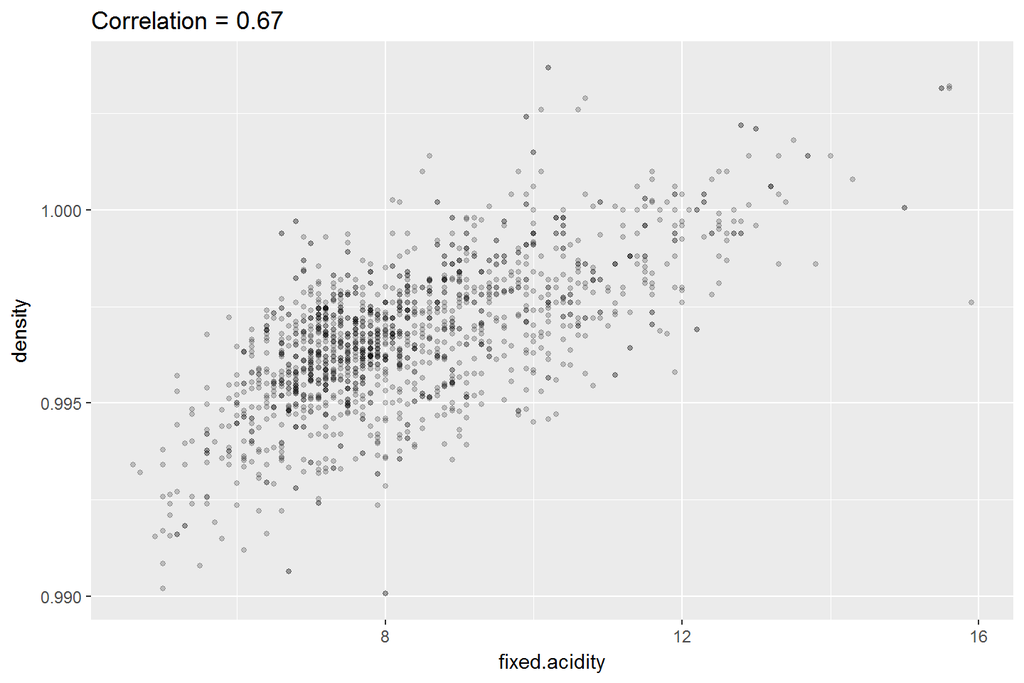

In the scatterplot of fixed acidity and density, we see that most observations are clustered in the midpart of the graph. The correlation of +0.67 is pretty strong. There is a logical explanation for that. The most common types of fixed acids are: citric acid, tartaric acid, and malic acid. All these acids have a higher density than water’s density. This means that the more fixed acids we have in red wine, the more dense it will be.

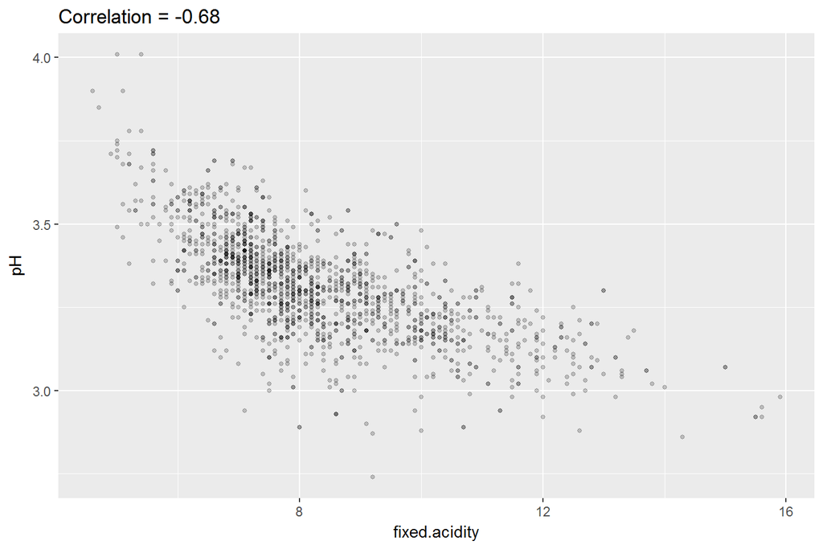

Regarding the relationship between fixed acidity and pH, we observe a negative association. The correlation is -0.68. This means that the more fixed acids we have in red wine, the lower its pH will be.

We will analyze now the relationship between alcohol and quality, since alcohol is the variable that correlates the most with quality.

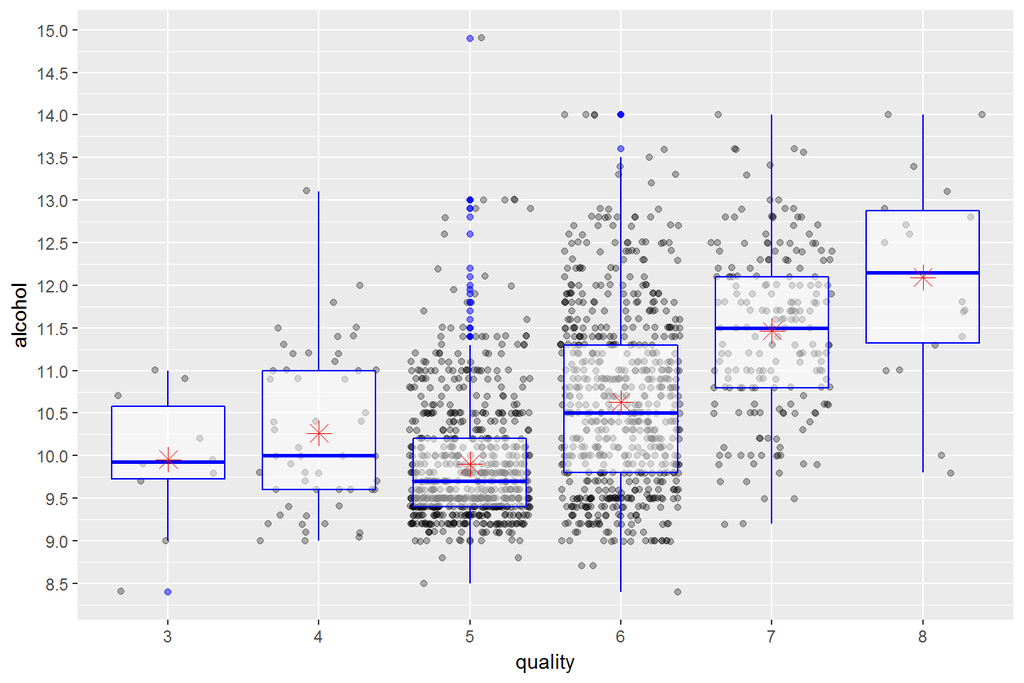

In the correlations plot, we also notice a negative correlation between volatile acidiy and quality of red wine (-0.39). We will analyze the boxplots for these variables below.

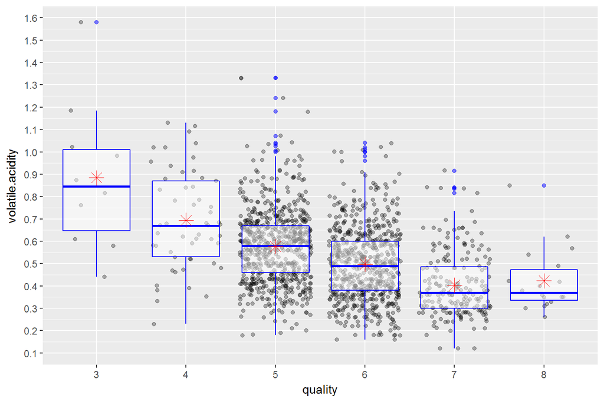

Indeed, the negative correlation between the two is resembled in these boxplots as well. The highest quality red wines have the lowest median volatile acidity content. Again, the most frequent quality red wines (5 and 6) have the most outliers regarding volatile acidity. The median values of volatile acidity for the red wines with quality levels of 5 and 6 are 0.58 (g/dm^3) and 0.49 (g/dm^3), respectively.

Since there is a positive correlation of 0.25 between sulphates and quality of red wine, we will investigate this relationship as well.

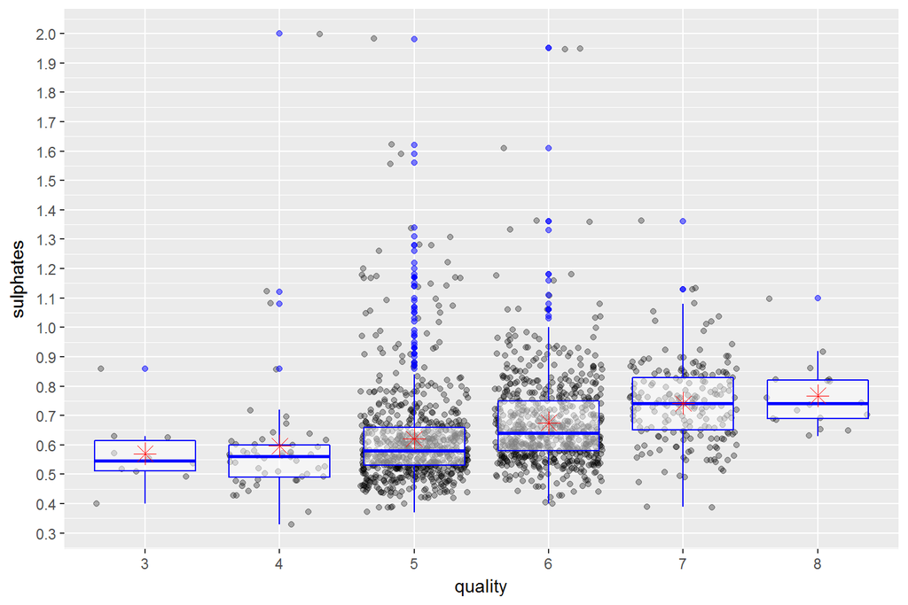

The positive correlation is resembled in these boxplots as well. Although it is quite small (0.25 only), we can notice that the higher quality red wines have higher median sulphates values. Just like before, we can observe that the most frequent quality red wines (5 and 6) have the most outliers regarding the sulphates content. The median values of sulphates of these wines with quality levels of 5 and 6 are 0.58 (g/dm^3) and 0.64 (g/dm^3) respectively.

# Bivariate Analysis

In this section, we looked at the relationships between the variables of our dataset. We used the correlation plot for that. We mostly paid attention to the strongest correlations, both positive and negative. The strongest positive correlation overall was 0.67 and the strongest negative correlation was -0.68. We graphed the scatterplots of these variables for a better visual understanding.

Since we are interested to know which chemical properties affect the quality of red wine, we investigated the relationships between some chemical properties and the quality of wine. The strongest correlation was between the alcohol content and the quality. We used boxplots to see visually that higher quality wines have indeed higher median alcohol contents. The highest quality red wine has an alcohol content of around 12.2%. With the same logic, we had a look at two more rather strong correlations. The volatile acidity content correlates negatively with the red wine quality (-0.39). And the sulphates have a small positive correlation with the red wine quality (0.25). The boxplots also show that the directions of these correlations make sense.

What’s interesting to notice, is that the most frequent quality red wines (5 and 6) had the most outliers regarding the chemical properties we investigated. The reason is that the correlations we investigated are not even close to being perfect (i.e. 1 or -1). Hence the relationship between those variables and the wine quality is not perfectly linear. I.e. more alcohol content does not necessarily mean a higher quality, or a higher volatile acidity content does not necessarily mean a lower quality of red wine.

We will investigate how we can best predict the quality of the red wine in the upcoming section.